# Causal Effect of Job Class on Wage of Males from the Atlantic Region of the United States

Fei Zhang, Kai Zhang, Hongyao Zhu

Jul 14, 2020

# Background story

```r
# Load the data
data("Wage")

# Clean the data
dat = Wage[, c(1:5,8,9,11)]
dat$A = Wage$jobclass

dat$race = as.factor(dat$race)
dat$education = as.factor(dat$education)
dat$health = as.factor(dat$health)
dat$health_ins = as.factor(dat$health_ins)
dat$A = as.factor(dat$A)
```

This dataset is used in the book “An Introduction to Statistical Learning” and was manually assembled by Steve Miller, of Open BI (www.openbi.com), from the March 2011 Supplement to Current Population Survey data. The original total dataset can be found at https://data.census.gov/mdat/#/ in the CPS Annual Social and Economic (March) Supplement. We downloaded the dataset `Wage` from package `ISLR`.

This dataset contains information about a group of 3000 males from the Atlantic region of the United States. Details of the code book of the dataset is shown in the appendix.

We are interested in the causal effect of job class to the wage in such a population.

# Step 0: Scientific question

We are interesting in evaluating the effect of job class on the wage of males from the Atlantic region of the United States.

Covariates of interest will include:  
$W_1$: Age  
$W_2$: Race, including White, Black, Asian and Others  
$W_3$: Education level  
$W_4$: Martial status  
$W_5$: Health level of worker  
$W_6$: Year that wage information was recorded  
$W_7$: Whether worker has health insurance  
$A$: Exposure, type of job, including industrial and information job  
$Y$: Outcome, workers raw wage

Covariate $W = \{W_1, W_2, W_3, W_4, W_5,W_6, W_7\}$

# Step 1: Causal model representing real knowledge

Our problem can be translated into the following structural causal model (SCM):

Endogenous nodes: $X = (W, A, Y)$  
Background (exogenous) variables: $U = (U_W,U_A,U_Y)$ ~ $P^*$  
Structural equations F:

$$\begin{align}
W &\leftarrow f_{W}(U_{W}) \\
A &\leftarrow f_{A}(W, U_{A}) \\
Y &\leftarrow f_{Y}(W, A, U_{Y}) \\
\end{align}$$

The DAG of this SCM is shown below:

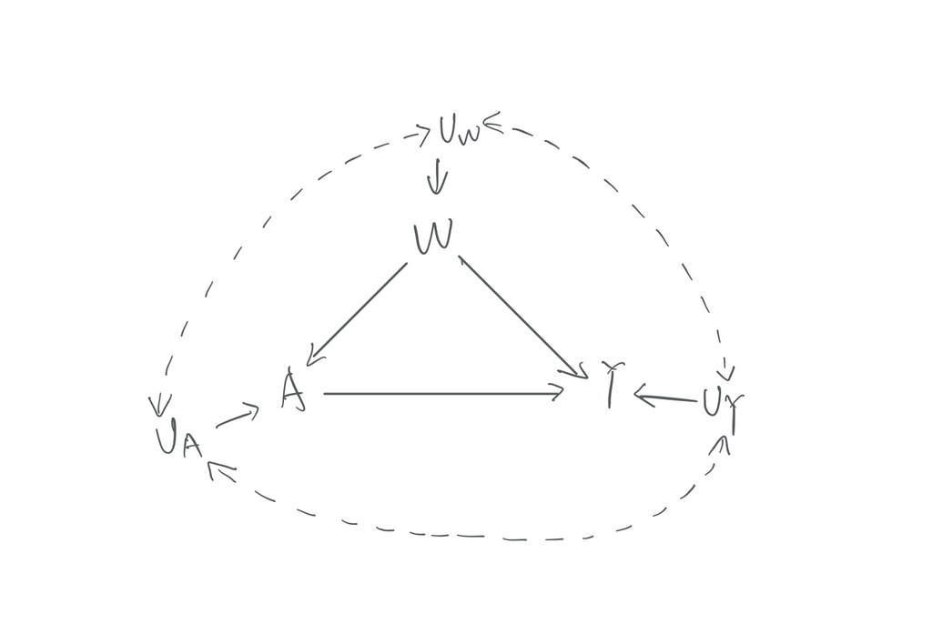

**Fig1.** The DAG of the SCM

# Step 2: Counterfactuals & causal parameter

The counterfactuals are $Y_1$ and $Y_0$.

$Y_0$: the solution of the equation $f_Y$ under an intervention on the system of equations to set $A=0$, e.g., all the observations had Industrial job class with input $U=u$. $Y_0=f_Y(W, A=0, U_Y)$

$Y_1$: the solution of the equation $f_Y$ under an intervention on the system of equations to set $A=1$, e.g., all the observations had Information job class with input $U=u$. $Y_1=f_Y(W, A=1, U_Y)$

We first draw all the $U$ from $P^*$ and generate all $W$ as deterministric function of all the $U_W$. Then we set A deterministically to 1 in order to generate $Y_1(U)$ as a deterministric function of $(W, A, U_Y)$. We can set A to 0 in order to generate $Y_0(U)$ similarly.

The target causal parameter is the average treatment effect (ATE):

$$\begin{align*}
\theta^*(\mathrm{P}^*) &= \mathrm{E}^*(Y_1) - \mathrm{E}^*(Y_0) \\
&= \mathrm{E}^*\big[ f_{Y}(W, 1, U_{Y}) \big] - \mathrm{E}^*\big[ f_{Y}(W, 0, U_{Y}) \big]
\end{align*}$$

Our target causal parameter, ATE, is the difference in the expected counterfactual wage if all observations had an Information job class and the expected counterfactual wage if all observations had Industrial job class.

# Step 3: Observed data & link to causal model

We assume that the observed data were generated by a system compatible with (described by) our structural causal model. The distribution of the background variables $\mathrm{P}^*$ and the structural equations $F$ identifies the distribution of the observed data $O$. If we knew the distribution of $U$ and the functions $F$, we would know the distribution of $O$. Thus, the causal model has implications for the distribution of $O$. These implications are testable.

Table 1 was created to describe our observed data.

```r
library(table1)
label(dat$age) = 'Age'
label(dat$maritl) = "Matrital Status"
label(dat$race) = "Race"
label(dat$education) = "Education Level"
label(dat$health) = "Health Status"
label(dat$health_ins) = "Health Insurance"
label(dat$A) = "Job Class"
label(dat$year) = "Year"
label(dat$wage) = "Wage"
table1(~age+maritl+race+education+health+health_ins+year+wage|A, data = dat,
       caption = "TABLE 1. The Summary Table of Mid-Atlantic Wage Data",
       footnote = "Note: The unit of wage is U.S.dollar.")
```

TABLE 1. The Summary Table of Mid-Atlantic Wage Data

|  | 1. Industrial (N=1544) | 2. Information (N=1456) | Overall (N=3000) |
| --- | --- | --- | --- |
| Age |  |  |  |
| Mean (SD) | 41.4 (11.7) | 43.5 (11.3) | 42.4 (11.5) |
| Median [Min, Max] | 41.0 [18.0, 80.0] | 43.0 [18.0, 80.0] | 42.0 [18.0, 80.0] |
| Matrital Status |  |  |  |
| 1. Never Married | 357 (23.1%) | 291 (20.0%) | 648 (21.6%) |
| 2. Married | 1046 (67.7%) | 1028 (70.6%) | 2074 (69.1%) |
| 3. Widowed | 12 (0.8%) | 7 (0.5%) | 19 (0.6%) |
| 4. Divorced | 103 (6.7%) | 101 (6.9%) | 204 (6.8%) |
| 5. Separated | 26 (1.7%) | 29 (2.0%) | 55 (1.8%) |
| Race |  |  |  |
| 1. White | 1325 (85.8%) | 1155 (79.3%) | 2480 (82.7%) |
| 2. Black | 111 (7.2%) | 182 (12.5%) | 293 (9.8%) |
| 3. Asian | 86 (5.6%) | 104 (7.1%) | 190 (6.3%) |
| 4. Other | 22 (1.4%) | 15 (1.0%) | 37 (1.2%) |
| Education Level |  |  |  |
| 1. < HS Grad | 190 (12.3%) | 78 (5.4%) | 268 (8.9%) |
| 2. HS Grad | 636 (41.2%) | 335 (23.0%) | 971 (32.4%) |
| 3. Some College | 342 (22.2%) | 308 (21.2%) | 650 (21.7%) |
| 4. College Grad | 274 (17.7%) | 411 (28.2%) | 685 (22.8%) |
| 5. Advanced Degree | 102 (6.6%) | 324 (22.3%) | 426 (14.2%) |
| Health Status |  |  |  |
| 1. <=Good | 487 (31.5%) | 371 (25.5%) | 858 (28.6%) |
| 2. >=Very Good | 1057 (68.5%) | 1085 (74.5%) | 2142 (71.4%) |
| Health Insurance |  |  |  |
| 1. Yes | 969 (62.8%) | 1114 (76.5%) | 2083 (69.4%) |
| 2. No | 575 (37.2%) | 342 (23.5%) | 917 (30.6%) |
| Year |  |  |  |
| Mean (SD) | 2010 (2.05) | 2010 (2.00) | 2010 (2.03) |
| Median [Min, Max] | 2010 [2000, 2010] | 2010 [2000, 2010] | 2010 [2000, 2010] |
| Wage |  |  |  |
| Mean (SD) | 103 (35.1) | 121 (46.1) | 112 (41.7) |
| Median [Min, Max] | 99.7 [23.0, 296] | 113 [20.1, 318] | 105 [20.1, 318] |

Note: The unit of wage is U.S.dollar.

# Step 4: Identification

In the original structural causal model, the target causal parameter is not identified from the observed data distribution. For identifiability to hold, we would need the following independence assumptions to hold: $U_A \perp U_Y$ and (i) $U_A \perp U_{W}$, or (ii) $U_Y \perp U_{W}$. We also need the positivity assumption to hold
$$0 < P(A=1|W=w) < 1$$
for all $w$ for which $\mathrm{P}(W=w) >0$. In terms of our dataset, there must be a positive probability of the subjects with Information job class within strata of baseline covariates.

In this study, we have covariates (age, marital status, race, education level, health status, health insurance, and the recording year), representing the objective conditions of a person. Subjective conditions like personality or personal preference may affect job classes but not the wage. Therefore, from a material perspective, give assumptions discussed above, our target causal parameter can be identified. And $U_A \perp U_Y$, together with $U_Y \perp U_W$ may be more plausible. More variables such as family members’ job class, family members’ wages may also be included.

# Step 5: Specify the statistical estimand

The target statistical estimand is given by the G-Computation formula:
$$\begin{align*}
\theta &= \mathrm{E}\big[ \mathrm{E}(Y|A=1, W) - \mathrm{E}(Y|A=0,W) \big] \\
&= \sum_w \big[ \mathrm{E}(Y|A=1, W=w) -\mathrm{E}(Y|A=0, W=w) \big]\mathrm{P}(W=w)
\end{align*}$$

# Step 6: Estimate

The target causal parameter, the average treatment effect, was estimated using four different estimators, including G-Computation, IPTW, AIPW, and TMLE, using data-adaptive methods. When we apply an estimator to our observed data ($n$ i.i.d. copies of $O$ drawn from $\mathrm{P}$), we can get an estimate (a number). The estimator is a function of random variables, so it is a random variable. It has a distribution, which we can study theoretically or using simulations. An estimator is consistent if the point estimates converge (in probability) to the estimand as sample size $n \rightarrow \infty$.

To estimate outcome variable ( *Wage* ), Super Learner includes libraries in the following:

- biglasso.
- glmnet.
- Gradient Boosting Machine (n.tree = 100, max.depth = 1, learing rate = 0.1).
- Random Forest (n.tree = 500).
- XGBoost (n.tree = 500, max.depth = 3, learning rate = 0.01).

To estimate exposure variable ( *type of job* ), Super Learner includes libraries in the following:

- Logistic Regression.
- K Nearest Neighbors (K = 50).
- Gradient Boost Machine (n.tree = 1000, max.depth = 1, learning rate = 0.1)
- Random Forest (n.trees = 100)
- XGBoost (n.tree = 1000, max.depth = 1, learning rate = 0.1).

The process of tuning hyperparameters of the above algorithms is shown in *Appendix*, with newly defined superlearner libraries. By tuning the hyperparameters, especially for ensemble methods, we achieved higher accuracy and less computing time.

```r
# tuned libraries for estimating outcome
gbm.outcome = function(...) {
  SL.gbm(...,gbm.trees = 100, interaction.depth = 1, shrinkage = 0.1)
}

rf.outcome = function(...){
  SL.ranger(...,num.trees = 500)
}

xg.outcome = function(...){
  SL.xgboost(...,ntrees = 500, max_depth = 3, shrinkage = 0.01)
}

outcome_library = c("SL.biglasso", "SL.glmnet", "SL.mean",
                    "rf.outcome", "gbm.outcome", "xg.outcome")

# tuned libraries for estimating exposure
gbm.exposure = function(...) {
  SL.gbm(...,gbm.trees = 1000, interaction.depth = 1, shrinkage = 0.1)
}

rf.exposure = function(...){
  SL.ranger(...,num.trees = 100)
}

xg.exposure = function(...){
  SL.xgboost(...,ntrees = 1000, max_depth = 1, shrinkage = 0.1)
}

knn.exposure = function(...){
  SL.knn(...,k = 50)
}

exposure_library = c("gbm.exposure", "rf.exposure",
                     "xg.exposure", "knn.exposure",
                     "SL.glm", "SL.mean")
```

To calculate the standard error of these four estimators, the bootstrap method was used. We created a function `four_est()` to simultaneously perform bootstrap on the four estimators and adopt parallel computing (snow) to accelerate computing. Specifically, we resampled the data with replacement 200 times (See *Appendix*).

```r
library(boot)
# configure snow for parallel computing
clusterExport(cluster, outcome_library)
clusterExport(cluster, exposure_library)
clusterExport(cluster, "four_est")
results = boot(data=dat,
               statistic = four_est,
               R = 200,
               SL.m = outcome_library,
               SL.g = exposure_library,
               parallel = "snow",
               cl = cluster)

# save the boostrap results
save(results,"boot_data.RData")
```

## Performance evaluation

Two-layer cross-validation is used to evaluate the performance of each SL libraries and Super Learner.

```r
library(SuperLearner)

cv_outcome = CV.SuperLearner(Y = dat$wage,
                             X = X,
                             family = gaussian(),
                             # For a real analysis we use V = 10
                             V = 10,
                             parallel = cluster,
                             SL.library = outcome_library)

cv_exposure = CV.SuperLearner(Y = dat$A,
                              X = dplyr::select(X, -A),
                              family = binomial(),
                              # For a real analysis we use V = 10
                              V = 10,
                              parallel = cluster,
                              SL.library = exposure_library)
```

### Outcome

```
##
## Call:
## CV.SuperLearner(Y = dat$wage, X = X, V = 10, family = gaussian(), SL.library = outcome_library,
##     parallel = cluster)
##
## Risk is based on: Mean Squared Error
##
## All risk estimates are based on V =  10
##
##        Algorithm    Ave     se     Min    Max
##    Super Learner 1138.1 62.842  626.95 1569.0
##      Discrete SL 1156.7 63.368  646.39 1590.0
##  SL.biglasso_All 1162.3 62.655  648.36 1577.5
##    SL.glmnet_All 1162.3 62.662  648.25 1577.3
##      SL.mean_All 1742.2 83.173 1121.02 2250.0
##   rf.outcome_All 1144.6 62.547  646.39 1576.1
##  gbm.outcome_All 1151.0 62.472  636.15 1547.3
##   xg.outcome_All 1148.9 63.383  627.59 1590.0
```

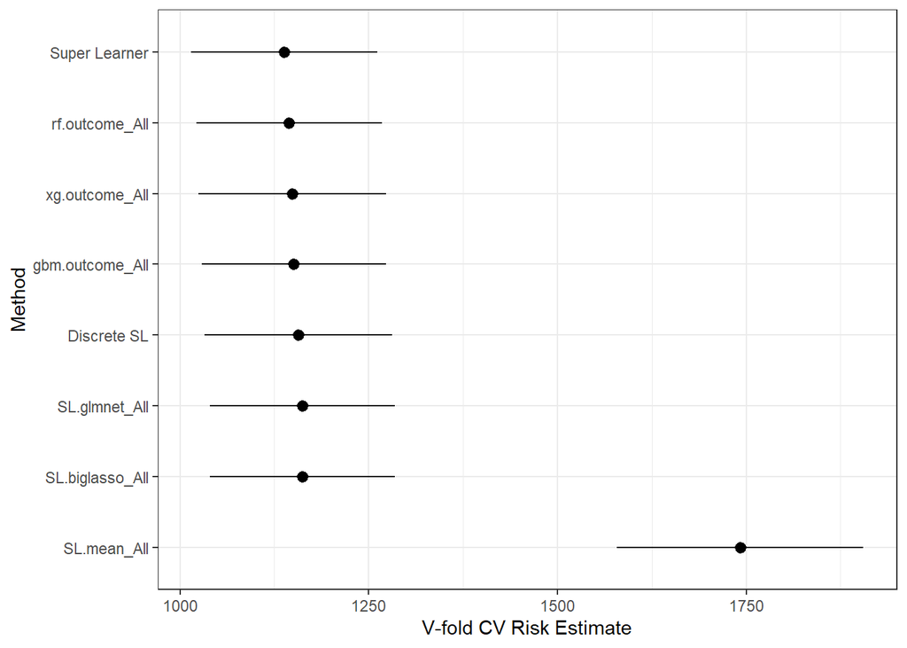

### Exposure

For Super Learner estimating exposure/treatment variables, the mean risk estimations of all algorithms are similar. Specifically, the risk for simple mean is the maximum(risk = 0.25) with the minimum standard error across the folds. While the general linear regression algorithm owns the minimum cross-validated risk(risk = 0.2221) compared to all algorithms.

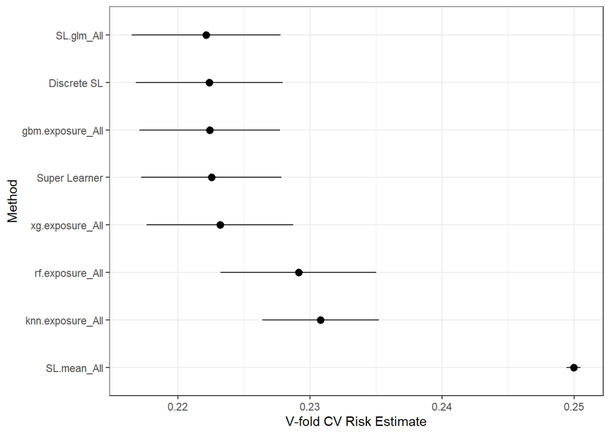

```
##
## Call:
## CV.SuperLearner(Y = dat$A, X = dplyr::select(X, -A), V = 10, family = binomial(),
##     SL.library = exposure_library, parallel = cluster)
##
## Risk is based on: Mean Squared Error
##
## All risk estimates are based on V =  10
##
##         Algorithm     Ave        se     Min     Max
##     Super Learner 0.22255 0.0027079 0.20577 0.23211
##       Discrete SL 0.22239 0.0028413 0.20653 0.23411
##  gbm.exposure_All 0.22242 0.0027113 0.20919 0.23363
##   rf.exposure_All 0.22914 0.0030035 0.20938 0.23612
##   xg.exposure_All 0.22320 0.0028318 0.20958 0.23385
##  knn.exposure_All 0.23081 0.0022522 0.21241 0.23844
##        SL.glm_All 0.22215 0.0028744 0.20653 0.23411
##       SL.mean_All 0.24996 0.0002737 0.24894 0.25140
```

## Simple substitution estimator based on the G-Computation

The G-Computation estimator is:

$$\hat{\theta}_{G-comp} = \frac{1}{n} \sum_{i=1}^n \bigg( \hat{\mathrm{E}}(Y_i | A_i=1,W_i) - \hat{\mathrm{E}}(Y_i | A_i=0,W_i) \bigg)$$

where $\hat{\mathrm{E}}(Y| A,W)$ is the estimator of the conditional mean outcome given the exposure (children attending the after school reading program or not) and baseline covariates $\mathrm{E}(Y|A,W)$. Consistency of the simple (non-targeted) substitution estimator depends on the consistent estimation of the conditional mean outcome $\mathrm{E}(Y|A,W)$.

### SuperLearner Result

```r
SL.outcome=snowSuperLearner(dat$wage, X, family = gaussian(),
                            cvControl = list(V=10),
                            SL.library = outcome_library,
                            cluster = cluster)

ma = predict(SL.outcome, newdata = X, onlySL = TRUE)$pred
m1 = predict(SL.outcome, newdata = X1, onlySL = TRUE)$pred
m0 = predict(SL.outcome, newdata = X0, onlySL = TRUE)$pred

mean(m1-m0); # 3.254
```

```
##
## Call:
## snowSuperLearner(cluster = cluster, Y = dat$wage, X = X, family = gaussian(),
##     SL.library = outcome_library, cvControl = list(V = 10))
##
##
##                     Risk      Coef
## SL.biglasso_All 1160.335 0.2006063
## SL.glmnet_All   1160.448 0.0000000
## SL.mean_All     1741.624 0.0000000
## rf.outcome_All  1147.541 0.3347914
## gbm.outcome_All 1149.348 0.1098917
## xg.outcome_All  1143.416 0.3547106
```

```
## [1] 3.254395
```

The estimated ATE using G-computation is 3.254.

### Bootstrap Result

The bootstrap result for G-Computation is shown in the following figure. The estimates look as though they are following a normal distribution, though the substitution estimator is not asymptotically normal in theory.

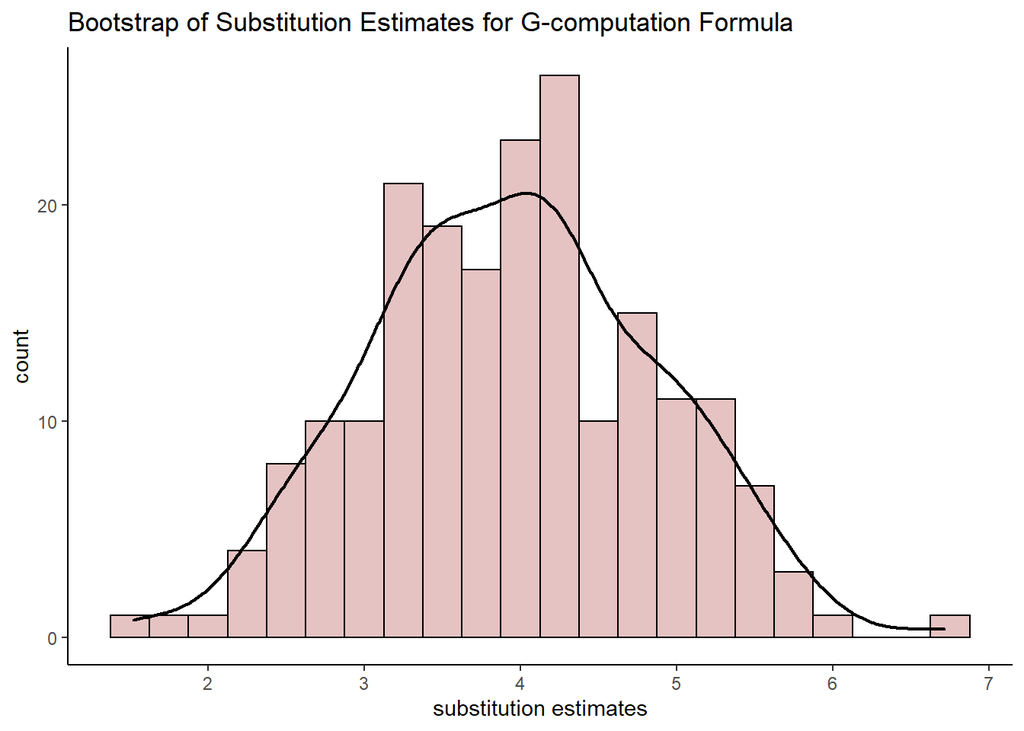

## Standard (unstabilized) inverse probability weighted estimator (IPTW)

The IPTW estimator is:

$$\hat{\theta}_{IPTW} = \frac{1}{n}\sum_{i=1}^n \left( \frac{\mathrm{I}(A_i=1)}{\hat{\mathrm{P}}(A_i=1|W_i)} -
\frac{\mathrm{I}(A_i=0)}{\hat{\mathrm{P}}(A_i=0|W_i)} \right) Y_i$$

where $\hat{\mathrm{P}}(A=1|W)$ is the estimator of the exposure mechanism (i.e. the conditional probability of attending the program, given the baseline covariates). Consistency of IPTW estimators depends on consistent estimation of the exposure mechanism $\mathrm{P}(A|W)$.

### SuperLearner Result

```r
SL_exposure = snowSuperLearner(Y=dat$A, X=dplyr::select(X, -A),
                           family = binomial(),
                           cvControl = list(V=10),
                           SL.library = exposure_library,
                           cluster = cluster)

#save(SL_exposure, file = "g.Rdata")
```

```
##
## Call:
## snowSuperLearner(cluster = cluster, Y = dat$A, X = dplyr::select(X, -A),
##     family = binomial(), SL.library = exposure_library, cvControl = list(V = 10))
##
##
##
##                       Risk       Coef
## gbm.exposure_All 0.2226626 0.03328041
## rf.exposure_All  0.2277321 0.19036073
## xg.exposure_All  0.2233446 0.06583254
## knn.exposure_All 0.2307346 0.11908896
## SL.glm_All       0.2227286 0.59143735
## SL.mean_All      0.2498825 0.00000000
```

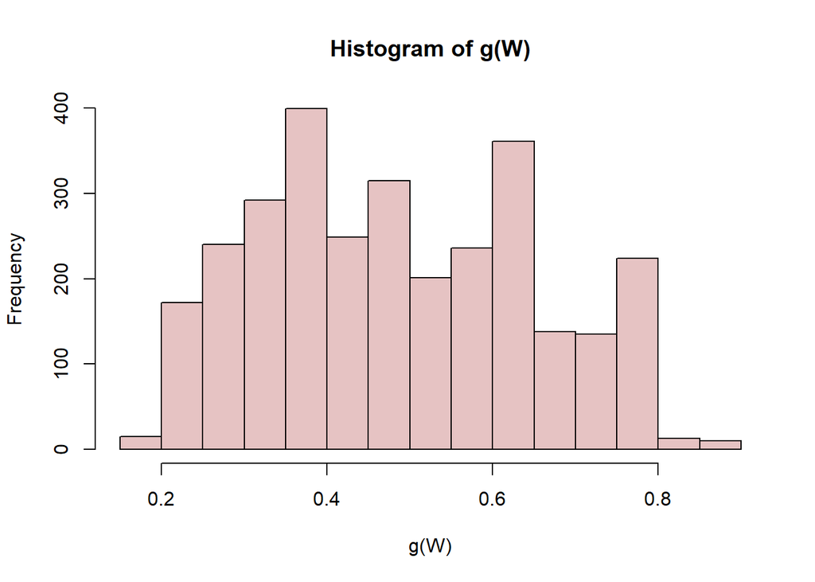

The distribution of g(w) has large variance and is away from 0. As a result, the positivity assumption is met. We can also check the non-stabilized weights.

```r
summary(1/gw)
```

```
##        V1
##  Min.   :1.146
##  1st Qu.:1.626
##  Median :2.116
##  Mean   :2.340
##  3rd Qu.:2.831
##  Max.   :6.130
```

The non-stabilized weight has a range of (1.146, 6.130), which is reasonable, and no observation has extreme weight.

Next, we used IPTW without stabilization and truncation to estimate the causal parameter, which is 4.726.

```r
H_AW = c(1:nrow(dat))
H_AW[dat$A==1] = 1/gw[dat$A==1]
H_AW[dat$A==0] = -1/(1-gw[dat$A==0])
H_1W = 1/gw
H_0W = -1/(1-gw)
mean(H_AW*dat$wage)
```

```
## [1] 4.725991
```

Next, as the guidelines require, we truncating $\hat{P}(A=1|W)$ by 1% and 5% to evaluating the sensitivity to different truncation level (though the minimal value for $\hat{P}(A=1|W)$ is 0.163, which we think there is no need to truncate). We dropped the smallest 1% (30 observations) of g(W) and 5% (150 observations) of g(W) from the dataset and calculated ATE using IPTW with truncated g(W).

The estimated ATE using IPTW is 5.588, with 1% level of truncation.

```r
gw.1 = gw[gw>quantile(gw, 0.01)]
gw.5 = gw[gw>quantile(gw, 0.05)]
H_AW.1 = H_AW[gw>quantile(gw, 0.01)]
H_AW.5 = H_AW[gw>quantile(gw, 0.05)]
H_1W.1 = 1/gw.1
H_1W.5 = 1/gw.5
H_0W.1 = -1/(1-gw.1)
H_0W.5 = -1/(1-gw.5)
mean(H_AW.1*dat$wage[gw>quantile(gw, 0.01)])
```

```
## [1] 5.588054
```

The estimated ATE using IPTW is 9.133 with 5% level of truncation.

```r
mean(H_AW.5*dat$wage[gw>quantile(gw, 0.05)])
```

```
## [1] 9.133023
```

### Bootstrap Result

The bootstrap result for IPTW estimators is shown below. All three seem like following a normal distribution, though this is not guaranteed by theory (asymptotical linearity and normality is not the property of IPTW).

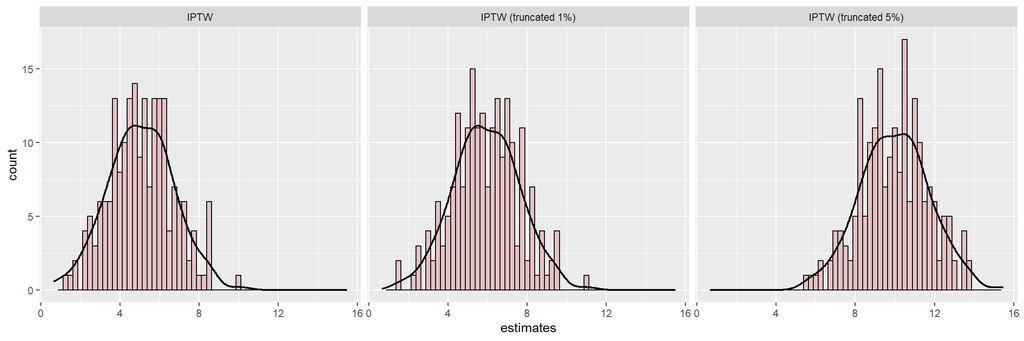

## Augmented inverse probability weighted estimator (AIPW)

The AIPW estimator is:

$$\hat{\theta}_{AIPW} = \frac{1}{n} \sum_{i=1}^n \bigg\{\frac{A_i}{\hat{g}(W_i)} [Y_i-\hat{m}(W_i)] + \hat{m}(W_i) \bigg\}$$

Where $\hat{g}(W_i)$ is our estimated $P(A=1|W)$, and $\hat{m}(W)$ is our estimated $E(Y|A=1, W)$. Implementation requires estimation of both the conditional mean function $\mathrm{E}(Y|A,W)$ and the exposure mechanism $g(W)=\mathrm{P}(A=1|W)$. Double robust estimators are consistent if either $\mathrm{E}(Y|A,W)$ or $\mathrm{P}(A|W)$ are estimated consistently. If both $\mathrm{E}(Y|A,W)$ and $\mathrm{P}(A|W)$ are estimated consistently, AIPW will be efficient (achieve the lowest possible asymptotic variance). These asymptotic properties describe what happens when sample size goes to infinity and also translate into lower bias and variance in finite samples.

### SuperLearner Result

We first implement AIPW without truncating $\hat{P}(A=1|W)$, which is 7.417.

```r
mean(H_1W*(dat$wage-m1)+m1 - (H_0W*(dat$wage-m0)+m0))
```

```
## [1] 7.416641
```

Similarly, 1% and 5% truncation levels were applied to AIPW estimator. The AIPW estimated ATE with truncation level of 1% is 7.481.

```r
m1.1 = m1[gw>quantile(gw, 0.01)]
m1.5 = m1[gw>quantile(gw, 0.05)]
m0.1 = m0[gw>quantile(gw, 0.01)]
m0.5 = m0[gw>quantile(gw, 0.05)]
mean(H_1W.1*(dat$wage[gw>quantile(gw, 0.01)]-m1.1)+m1.1 - (H_0W.1*(dat$wage[gw>quantile(gw, 0.01)]-m0.1)+m0.1))
```

```
## [1] 7.481174
```

The AIPW estimated ATE with truncation level of 5% is 8.278.

```r
mean(H_1W.5*(dat$wage[gw>quantile(gw, 0.05)]-m1.5)+m1.5 - (H_0W.5*(dat$wage[gw>quantile(gw, 0.05)]-m0.5)+m0.5))
```

```
## [1] 8.277714
```

### Bootstrap Result

Additionally, the bootstrap results for AIPW estimators are shown in the following figure. Estimates from AIPW without truncation (left panel) and with truncation level 5% (right panel) follow a normal distribution, while AIPW with truncation level 1% (middle panel) is sightly bimodal. By theory, the AIPW should be asymptotically normal if a consistent estimator predicts $ g$ and $m$.

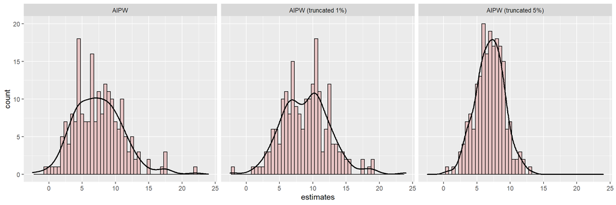

```r
boot.t %>%
  select("AIPW", "AIPW (truncated 1%)","AIPW (truncated 5%)") %>%
  melt() %>%
  ggplot(aes(x = value)) +
  geom_histogram(fill = "#e6c3c3", color = "black",binwidth = 0.5, bins = 20)+
  geom_density(aes(y=0.5 * ..count..), lwd = 0.75) +
  xlim(range(boot.t$AIPW,boot.t$`AIPW (truncated 1%)`,boot.t$`AIPW (truncated 5%)`))+
  facet_grid(~variable, scales = "free_x")+
  labs(x="estimates")
```

## Targeted maximum likelihood estimation (TMLE)

The TMLE estimator is:

$$\hat{\theta}_{TMLE} = \frac{1}{n} \sum_{i=1}^n \bigg[ \tilde{m}(A_i,W_i) \bigg]$$

where $\tilde{m}(A,W)$ denotes the targeted estimate of the conditional mean outcome, given the exposure and baseline covariates $\mathrm{E}(Y|A,W)$. Similar to AIPW, implementation requires estimation of $\mathrm{E}(Y|A,W)$ and $g(W)=\mathrm{P}(A=1|W)$. TMLE is also a double robust estimator and if both $\mathrm{E}(Y|A,W)$ and $\mathrm{P}(A|W)$ are estimated consistently, TMLE will be efficient. As TMLE will generate values in our target range, it will be preferred. These asymptotic properties describe what happens when sample size goes to infinity and also translates into lower bias and variance in finite samples.

### SuperLearner Result

The estimated ATE using hand code TMLE is 3.569.

```r
logit_update<- lm(dat$wage ~ -1 + offset(ma) + H_AW)
epsilon = coef(logit_update)

expY_givenAW_star = ma+epsilon*H_AW
expY_given1W_star = m1+epsilon*H_1W
expY_given0W_star = m0+epsilon*H_0W

estimates <- mean(expY_given1W_star-expY_given0W_star)
estimates
```

```
## [1] 3.569167
```

Similarly, 1% and 5% truncation levels were applied to TMLE estimator.

The estimated ATE using hand-code TMLE is 3.648, with 1% truncation.

```r
ma.1 = ma[gw>quantile(gw, 0.01)]
logit_update.1<- lm(dat$wage[gw>quantile(gw, 0.01)] ~ -1 + offset(ma.1) + H_AW.1)
epsilon.1 = coef(logit_update.1)

expY_given1W_star.1 = m1.1+epsilon.1*H_1W.1
expY_given0W_star.1 = m0.1+epsilon.1*H_0W.1
mean(expY_given1W_star.1-expY_given0W_star.1)
```

```
## [1] 3.648097
```

The estimated ATE using hand code TMLE is 3.662 with 5% truncation.

```r
ma.5 = ma[gw>quantile(gw, 0.05)]
logit_update.5<- lm(dat$wage[gw>quantile(gw, 0.05)] ~ -1 + offset(ma.5) + H_AW.5)
epsilon.5 = coef(logit_update.5)

expY_given1W_star.5 = m1.5+epsilon.5*H_1W.5
expY_given0W_star.5 = m0.5+epsilon.5*H_0W.5
mean(expY_given1W_star.5-expY_given0W_star.5)
```

```
## [1] 3.661799
```

```r
t = tmle(dat$wage, dat$A, X[,1:7],
     Q.SL.library = outcome_library,
     g.SL.library = exposure_library)
save(t, file = "est_tmle_function.Rdata")
```

```r
load("est_tmle_function.Rdata")
t$estimates$ATE
```

```
## $psi
## [1] 3.75625
##
## $var.psi
## [1] 1.506765
##
## $CI
## [1] 1.350343 6.162157
##
## $pvalue
## [1] 0.002212831
```

Estimation results using TMLE function is 3.756, with 95% CI (1.350, 6.162), which is similar to our hand coded TMLE estimator.

### Bootstrap Result

The bootstrap results for TMLE estimators are shown in the following figure. All three estimators seem to follow a normal distribution, which is consistent with the theory that TMLE is of asymptotical linearity and normality under a condition in which consistent estimators predict both $g$ and $m$.

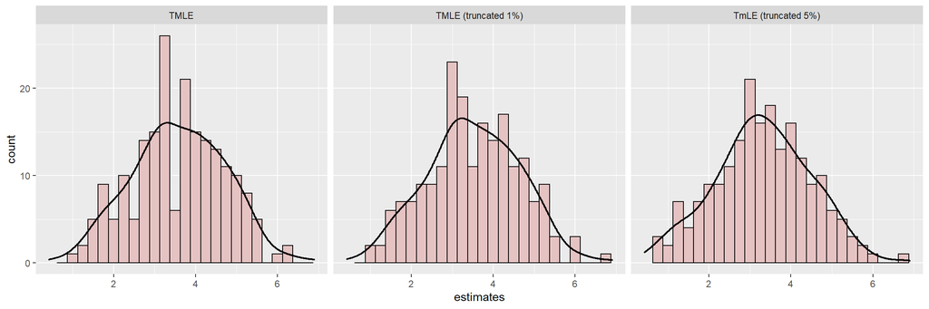

```r
boot.t %>%
  select("TMLE", "TMLE (truncated 1%)","TmLE (truncated 5%)") %>%
  melt() %>%
  ggplot(aes(x = value)) +
  geom_histogram(fill = "#e6c3c3", color = "black",binwidth = 0.25, bins = 20)+
  geom_density(aes(y=0.25 * ..count..), lwd = 0.75) +
  xlim(range(boot.t$TMLE,boot.t$`TMLE (truncated 1%)`,boot.t$`TmLE (truncated 5%)`))+
  facet_grid(~variable, scales = "free_x")+
  labs(x="estimates")
```

## Summary

To compare the estimates using different estimators, a table of summary is created.

```r
se = c('0.980','1.154','1.201','1.311',
       '3.237','3.489','4.057','1.310',
       '1.304','1.322', '1.507')
ests = c(3.254, 4.726, 5.588, 9.133,
         7.417, 7.481, 8.278, 3.569,
         3.648, 3.662, 3.756)
name = c("est.sub", "IPTW", "IPTW (truncated 1%)","IPTW (truncated 5%)",
         "AIPW", "AIPW (truncated 1%)","AIPW (truncated 5%)",
         "TMLE", "TMLE (truncated 1%)","TmLE (truncated 5%)", "TMLE (package result)")

ci = matrix(c('(0.801, 4.641)', '(2.069, 5.419)',
    '(1.458, 5.982)',   '(3.197, 6.922)',
  '(2.17, 6.899)',  '(3.991, 7.816)',
  '(4.317, 9.459)', '(8.019, 12.025)',
    '(0.29, 12.977)',   '(2.383, 13.242)',
    '(-1.657, 12.019)', '(3.931, 15.94)',
    '(-2.785, 13.119)', '(5.413, 19.244)',
    '(1.534, 6.671)',   '(1.372, 5.919)',
    '(1.754, 6.867)'    ,'(1.239, 5.846)',
    '(1.929, 7.111)',   '(0.907, 5.778)'), ncol = 2, byrow = TRUE)

df = cbind(name,ests,se,ci) %>% as.data.frame()
colnames(df) = c("Estimator","Point Estimate", "Standard Error","95% CI (Normal Approx.)","95% CI (Quantile)")
df[1,1] = "Substitution Estimator"
df2 = data.frame("TMLE (package result)", 3.756, 1.507, "(1.350, 6.162)", "NA")
names(df2) = names(df)
df = rbind(df, df2)

library(kableExtra)
df %>%
  kable(format = "html",table.attr = "style='width:85%;'",
        caption = "TABLE2. Summary of estimators" ) %>%
  kable_styling(bootstrap_options = c("striped", "hover", "condensed"), position = "center")
```

TABLE2. Summary of estimators

| Estimator | Point Estimate | Standard Error | 95% CI (Normal Approx.) | 95% CI (Quantile) |
| --- | --- | --- | --- | --- |
| Substitution Estimator | 3.254 | 0.980 | (0.801, 4.641) | (2.069, 5.419) |
| IPTW | 4.726 | 1.154 | (1.458, 5.982) | (3.197, 6.922) |
| IPTW (truncated 1%) | 5.588 | 1.201 | (2.17, 6.899) | (3.991, 7.816) |
| IPTW (truncated 5%) | 9.133 | 1.311 | (4.317, 9.459) | (8.019, 12.025) |
| AIPW | 7.417 | 3.237 | (0.29, 12.977) | (2.383, 13.242) |
| AIPW (truncated 1%) | 7.481 | 3.489 | (-1.657, 12.019) | (3.931, 15.94) |
| AIPW (truncated 5%) | 8.278 | 4.057 | (-2.785, 13.119) | (5.413, 19.244) |
| TMLE | 3.569 | 1.310 | (1.534, 6.671) | (1.372, 5.919) |
| TMLE (truncated 1%) | 3.648 | 1.304 | (1.754, 6.867) | (1.239, 5.846) |
| TmLE (truncated 5%) | 3.662 | 1.322 | (1.929, 7.111) | (0.907, 5.778) |
| TMLE (package result) | 3.756 | 1.507 | (1.350, 6.162) | NA |

In general, the truncation of $g(W)$ increases the point estimate of IPTW, AIPW, and TMLE estimators, and the estimate increases as the truncation level increases from 1% to 5%. The standard error of estimates also increases slightly with the increase of truncation level, except the TMLE estimator, the standard error are similar.

The substitution estimator has the smallest standard error. This may due to better libraries used for estimating $m(W)$, and our estimated $\hat{m}(W)$ is closer to the true $m(W)$. TMLE estimators also ahve a small standard error, while AIPW estimators have the largest standard error among these estimators.

# Step 7: Conclusion

This study also has several limitations. The population of this study is small. Further study may focus on both males and females in all regions of the United States. Also, time series analysis may also be applied to separate the effect of inflation from wages so that we can study the effect of job class itself more accurately. More variables, including family background, may also be included, as well as a larger library of a super learner, to improve our model.

# Appendix:

## Code book

age - continuous, age that wage information was recorded

race - race

- race = 1: White
- race = 2: Black
- race = 3: Asian
- race = 4: Other

education - education level

- education = 1: <HS Grad
- education = 2: HS Grad
- education = 3: Some College
- education = 4: College Grad
- education = 5: Advanced Degree

maritl - marital status

- maritl = 1: Never Married
- maritl = 2: Married
- maritl = 3: Widowed
- maritl = 4: Divorced
- maritl = 5: Separated

health - health level of worker

- health = 1: <= Good
- health = 2: >= Very Good

year - continuous, year that wage information was recorded

health_ins - whether worker has health insurance

- health_ins = 1: Yes
- health_ins = 2: No

jobclass - type of job

- jobclass = 1: Industrial
- jobclass = 2: Information

## Tuning Hyperparameters

Hyperparameters are the configuration settings for an algorithm, and the performance of an algorithm varies based on its hyperparameters. Here, we use `create.Learner` function to customize hyperparameters for our algorithms.

```r
# Create clusters
library(parallel)
cluster = makeCluster(4)
clusterEvalQ(cluster, library(SuperLearner))
```

### Outcome(Wages)

#### Tuning gbm for outcome

```r
# Tune gbm for outcome
gbm.learners = create.Learner("SL.gbm",
                              tune = list(gbm.trees = c(100, 500, 1000),
                                          interacion.depth = c(1,2),
                                          shrinkage = c(0.001, 0.01, 0.1)),
                              detailed_names = TRUE, name_prefix = "gbm")
clusterExport(cluster, gbm.learners$names)
clusterSetRNGStream(cluster, 1)
gbm.tune = CV.SuperLearner(dat$wage, X, family = gaussian(),
                           V=5,
                           SL.library = gbm.learners$names,
                           parallel = cluster)
save(gbm.tune, file = "gbm.outcome.Rdata")
```

```r
load("gbm.outcome.Rdata")
summary(gbm.tune)
```

```
##
## Call:
## CV.SuperLearner(Y = dat$wage, X = X, V = 5, family = gaussian(), SL.library = gbm.learners$names,
##     parallel = cluster)
##
## Risk is based on: Mean Squared Error
##
## All risk estimates are based on V =  5
##
##             Algorithm    Ave     se     Min    Max
##         Super Learner 1133.5 61.756  863.48 1365.5
##           Discrete SL 1135.1 61.893  863.65 1371.2
##   gbm_100_1_0.001_All 1677.2 81.343 1441.54 1974.0
##   gbm_500_1_0.001_All 1489.7 75.733 1245.45 1768.7
##  gbm_1000_1_0.001_All 1350.6 71.226 1098.30 1615.7
##   gbm_100_2_0.001_All 1677.5 81.335 1442.26 1973.4
##   gbm_500_2_0.001_All 1489.8 75.699 1244.83 1768.5
##  gbm_1000_2_0.001_All 1351.0 71.284 1098.91 1616.5
##    gbm_100_1_0.01_All 1350.3 71.276 1099.30 1613.1
##    gbm_500_1_0.01_All 1143.6 62.807  876.61 1380.8
##   gbm_1000_1_0.01_All 1136.0 62.129  863.65 1368.3
##    gbm_100_2_0.01_All 1348.8 71.105 1097.56 1616.1
##    gbm_500_2_0.01_All 1142.5 62.666  873.64 1383.1
##   gbm_1000_2_0.01_All 1135.1 62.090  863.79 1371.2
##     gbm_100_1_0.1_All 1133.0 61.532  858.63 1367.4
##     gbm_500_1_0.1_All 1133.7 61.141  865.43 1365.1
##    gbm_1000_1_0.1_All 1140.5 61.858  873.46 1363.2
##     gbm_100_2_0.1_All 1134.9 61.809  868.46 1371.2
##     gbm_500_2_0.1_All 1136.2 62.061  856.47 1369.3
##    gbm_1000_2_0.1_All 1136.7 61.805  863.86 1367.2
```

Using 5-fold cross validation, the tuned GBM for outcome has 100 trees with interaction depth 1 and shrinkage 0.1. It has the lowest risk and small se.

#### Tuning random forest for outcome

```r
# Tune random forest for outcome
rf.learners = create.Learner("SL.ranger",
                             tune = list(num.trees = c(100, 500, 1000)))
clusterExport(cluster, rf.learners$names)
rf.tune = CV.SuperLearner(dat$wage, X, family = gaussian(),
                          V=5,
                          SL.library = rf.learners$names,
                          parallel = cluster)
save(rf.tune, file = "rf.outcome.Rdata")
```

```r
load("rf.outcome.Rdata")
summary(rf.tune)
```

```
##
## Call:
## CV.SuperLearner(Y = dat$wage, X = X, V = 5, family = gaussian(), SL.library = rf.learners$names,
##     parallel = cluster)
##
## Risk is based on: Mean Squared Error
##
## All risk estimates are based on V =  5
##
##        Algorithm    Ave     se    Min    Max
##    Super Learner 1148.5 62.984 964.53 1328.9
##      Discrete SL 1149.2 63.027 964.76 1328.9
##  SL.ranger_1_All 1148.6 62.735 966.99 1329.9
##  SL.ranger_2_All 1147.6 62.896 961.70 1329.9
##  SL.ranger_3_All 1147.6 63.014 964.76 1328.9
```

Using 5-fold cross validation, the tuned random forest for outcome has 500 trees. It has the lowest risk and small se.

#### Tuning xgBoost for outcome

```r
# Tune xgboost for outcome
xg.learners = create.Learner("SL.xgboost",
                             tune = list(ntrees = c(100, 500, 1000),
                                         max_depth = 1:3,
                                         shrinkage = c(0.001, 0.01, 0.1)),
                             detailed_names = TRUE, name_prefix = "xgb")
clusterExport(cluster, xg.learners$names)
xg.tune = CV.SuperLearner(dat$wage, X, family = gaussian(),
                          V=5,
                          SL.library = xg.learners$names,
                          parallel = cluster)
save(xg.tune, file = "xg.outcome.Rdata")
```

```r
load("xg.outcome.Rdata")
summary(xg.tune)
```

```
##
## Call:
## CV.SuperLearner(Y = dat$wage, X = X, V = 5, family = gaussian(), SL.library = xg.learners$names,
##     parallel = cluster)
##
## Risk is based on: Mean Squared Error
##
## All risk estimates are based on V =  5
##
##             Algorithm     Ave      se     Min     Max
##         Super Learner  1812.8  85.817  1065.0  4028.8
##           Discrete SL  1147.7  62.644  1042.6  1242.8
##   xgb_100_1_0.001_All 11820.8 212.733 11495.8 12012.9
##   xgb_500_1_0.001_All  6125.7 158.854  5927.8  6277.4
##  xgb_1000_1_0.001_All  3158.1 120.340  3059.3  3275.5
##   xgb_100_2_0.001_All 11798.3 211.602 11482.0 11994.3
##   xgb_500_2_0.001_All  6042.1 154.398  5863.4  6184.0
##  xgb_1000_2_0.001_All  3035.6 114.944  2950.2  3138.6
##   xgb_100_3_0.001_All 11786.0 210.772 11481.5 11989.8
##   xgb_500_3_0.001_All  5996.1 152.082  5848.4  6131.7
##  xgb_1000_3_0.001_All  2985.6 112.128  2891.4  3088.9
##    xgb_100_1_0.01_All  3142.4 120.089  3044.3  3259.5
##    xgb_500_1_0.01_All  1229.4  67.184  1152.5  1300.7
##   xgb_1000_1_0.01_All  1179.2  64.105  1083.1  1256.0
##    xgb_100_2_0.01_All  3019.7 114.674  2935.1  3122.3
##    xgb_500_2_0.01_All  1164.8  64.123  1068.8  1247.5
##   xgb_1000_2_0.01_All  1149.8  62.584  1042.6  1239.5
##    xgb_100_3_0.01_All  2969.6 111.873  2875.3  3072.7
##    xgb_500_3_0.01_All  1149.4  63.318  1057.7  1238.4
##   xgb_1000_3_0.01_All  1150.1  62.383  1042.5  1245.2
##     xgb_100_1_0.1_All  1177.4  64.001  1080.0  1255.0
##     xgb_500_1_0.1_All  1151.9  62.424  1043.7  1246.8
##    xgb_1000_1_0.1_All  1153.7  62.299  1043.5  1254.0
##     xgb_100_2_0.1_All  1151.2  62.592  1044.1  1242.8
##     xgb_500_2_0.1_All  1167.4  62.658  1056.9  1267.4
##    xgb_1000_2_0.1_All  1188.6  63.322  1073.6  1288.7
##     xgb_100_3_0.1_All  1153.2  62.552  1047.6  1253.4
##     xgb_500_3_0.1_All  1225.6  64.614  1102.5  1349.1
##    xgb_1000_3_0.1_All  1275.9  66.183  1141.2  1420.1
```

Using 5-fold cross validation, the tuned xgBoost for outcome has 500 trees with interaction depth 3 and shrinkage 0.01. It has the lowest risk and small se.

### Exposure (Job Classes)

#### Tuning gbm for exposure

```r
# Tune gbm for exposure
gbm2.tune = CV.SuperLearner(Y=dat$A, X=dplyr::select(X, -A),
                           family = binomial(), V=5,
                           SL.library = gbm.learners$names,
                           parallel = cluster)
save(gbm2.tune, file = "gbm.exposure.Rdata")
```

```r
load("gbm.exposure.Rdata")
summary(gbm2.tune)
```

```
##
## Call:
## CV.SuperLearner(Y = dat$A, X = dplyr::select(X, -A), V = 5, family = binomial(),
##     SL.library = gbm.learners$names, parallel = cluster)
##
## Risk is based on: Mean Squared Error
##
## All risk estimates are based on V =  5
##
##             Algorithm     Ave         se     Min     Max
##         Super Learner 0.22272 0.00264110 0.21189 0.23299
##           Discrete SL 0.22286 0.00265494 0.21181 0.23294
##   gbm_100_1_0.001_All 0.24599 0.00036023 0.24541 0.24740
##   gbm_500_1_0.001_All 0.23563 0.00098720 0.23247 0.24029
##  gbm_1000_1_0.001_All 0.22927 0.00153307 0.22395 0.23595
##   gbm_100_2_0.001_All 0.24597 0.00036051 0.24541 0.24734
##   gbm_500_2_0.001_All 0.23562 0.00099175 0.23237 0.24036
##  gbm_1000_2_0.001_All 0.22925 0.00153131 0.22388 0.23593
##    gbm_100_1_0.01_All 0.22920 0.00153713 0.22389 0.23566
##    gbm_500_1_0.01_All 0.22235 0.00263977 0.21163 0.23312
##   gbm_1000_1_0.01_All 0.22287 0.00268672 0.21181 0.23330
##    gbm_100_2_0.01_All 0.22915 0.00154206 0.22390 0.23571
##    gbm_500_2_0.01_All 0.22256 0.00261054 0.21206 0.23294
##   gbm_1000_2_0.01_All 0.22237 0.00265510 0.21141 0.23269
##     gbm_100_1_0.1_All 0.22265 0.00262329 0.21280 0.23354
##     gbm_500_1_0.1_All 0.22283 0.00263890 0.21163 0.23367
##    gbm_1000_1_0.1_All 0.22180 0.00265002 0.21092 0.23215
##     gbm_100_2_0.1_All 0.22337 0.00270251 0.21283 0.23308
##     gbm_500_2_0.1_All 0.22315 0.00267110 0.21268 0.23389
##    gbm_1000_2_0.1_All 0.22311 0.00266002 0.21089 0.23423
```

Using 5-fold cross validation, the tuned GBM for outcome has 1000 trees with interaction depth 1 and shrinkage 0.1. It has the lowest risk and small se.

#### Tuning random forest for exposure

```r
# Tune random forest for exposure
rf2.tune = CV.SuperLearner(Y=dat$A, X=dplyr::select(X, -A),
                          family = binomial(), V=5,
                          SL.library = rf.learners$names,
                          parallel = cluster)
save(rf2.tune, file = "rf.exposure.Rdata")
```

```r
load("rf.exposure.Rdata")
summary(rf2.tune)
```

```
##
## Call:
## CV.SuperLearner(Y = dat$A, X = dplyr::select(X, -A), V = 5, family = binomial(),
##     SL.library = rf.learners2$names, parallel = cluster)
##
## Risk is based on: Mean Squared Error
##
## All risk estimates are based on V =  5
##
##        Algorithm     Ave        se     Min     Max
##    Super Learner 0.22747 0.0029901 0.21593 0.24296
##      Discrete SL 0.22765 0.0029901 0.21591 0.24302
##  SL.ranger_1_All 0.22718 0.0030268 0.21453 0.24341
##  SL.ranger_2_All 0.22787 0.0029870 0.21630 0.24302
##  SL.ranger_3_All 0.22751 0.0029866 0.21591 0.24381
```

Using 5-fold cross validation, the tuned random forest for outcome has 100 trees. It has the lowest risk but large se.

#### Tuning xgBoost for exposure

```r
# Tune xgboost for exposure
xg2.tune = CV.SuperLearner(Y=dat$A, X=dplyr::select(X, -A),
                          family = binomial(), V=5,
                          SL.library = xg.learners$names,
                          parallel = cluster)
save(xg2.tune, file = "xg.exposure.Rdata")
```

```r
load("xg.exposure.Rdata")
summary(xg2.tune)
```

```
##
## Call:
## CV.SuperLearner(Y = dat$A, X = dplyr::select(X, -A), V = 5, family = binomial(),
##     SL.library = xg.learners$names, parallel = cluster)
##
## Risk is based on: Mean Squared Error
##
## All risk estimates are based on V =  5
##
##             Algorithm     Ave         se     Min     Max
##         Super Learner 0.22346 0.00261402 0.21740 0.23493
##           Discrete SL 0.22390 0.00271965 0.21631 0.23789
##   xgb_100_1_0.001_All 0.24777 0.00018348 0.24747 0.24802
##   xgb_500_1_0.001_All 0.24190 0.00067635 0.24086 0.24334
##  xgb_1000_1_0.001_All 0.23765 0.00100426 0.23603 0.24020
##   xgb_100_2_0.001_All 0.24627 0.00024178 0.24573 0.24688
##   xgb_500_2_0.001_All 0.23713 0.00094832 0.23479 0.24013
##  xgb_1000_2_0.001_All 0.23187 0.00140814 0.22842 0.23650
##   xgb_100_3_0.001_All 0.24555 0.00026578 0.24503 0.24618
##   xgb_500_3_0.001_All 0.23487 0.00104566 0.23232 0.23836
##  xgb_1000_3_0.001_All 0.22938 0.00161507 0.22499 0.23541
##    xgb_100_1_0.01_All 0.23764 0.00100594 0.23599 0.24022
##    xgb_500_1_0.01_All 0.22568 0.00195198 0.22140 0.23232
##   xgb_1000_1_0.01_All 0.22353 0.00235890 0.21793 0.23224
##    xgb_100_2_0.01_All 0.23182 0.00141205 0.22835 0.23649
##    xgb_500_2_0.01_All 0.22429 0.00244228 0.21842 0.23487
##   xgb_1000_2_0.01_All 0.22394 0.00273343 0.21803 0.23641
##    xgb_100_3_0.01_All 0.22935 0.00161844 0.22497 0.23536
##    xgb_500_3_0.01_All 0.22426 0.00269898 0.21666 0.23789
##   xgb_1000_3_0.01_All 0.22534 0.00293086 0.21723 0.24120
##     xgb_100_1_0.1_All 0.22342 0.00238129 0.21781 0.23234
##     xgb_500_1_0.1_All 0.22238 0.00276087 0.21591 0.23238
##    xgb_1000_1_0.1_All 0.22218 0.00281561 0.21589 0.23151
##     xgb_100_2_0.1_All 0.22400 0.00274806 0.21783 0.23745
##     xgb_500_2_0.1_All 0.22621 0.00307871 0.21911 0.24338
##    xgb_1000_2_0.1_All 0.22839 0.00321583 0.22140 0.24710
##     xgb_100_3_0.1_All 0.22542 0.00294070 0.21735 0.24191
##     xgb_500_3_0.1_All 0.23137 0.00338920 0.22389 0.24851
##    xgb_1000_3_0.1_All 0.23757 0.00366981 0.22854 0.25171
```

Using 5-fold cross validation, the tuned xgBoost for exposure has 1000 trees with interaction depth 1 and shrinkage 0.1. It has the lowest risk and small se.

#### Tuning KNN for exposure

```r
# Tune knn for exposure
knn.learners = create.Learner("SL.knn",
                             tune = list(k = c(5, 10, 20, 50, 100)),
                             detailed_names = TRUE, name_prefix = "knn")
clusterExport(cluster, knn.learners$names)
knn.tune = CV.SuperLearner(Y=dat$A, X=dplyr::select(X, -A),
                          family = binomial(), V=5,
                          SL.library = knn.learners$names,
                          parallel = cluster)
save(knn.tune, file = "knn.exposure.Rdata")
```

Using 5-fold cross validation, the tuned KNN for exposure has 50 neighbours. It has the lowest risk and small se.

```r
load("knn.exposure.Rdata")
summary(knn.tune)
```

```
##
## Call:
## CV.SuperLearner(Y = dat$A, X = dplyr::select(X, -A), V = 5, family = binomial(),
##     SL.library = knn.learners$names, parallel = cluster)
##
## Risk is based on: Mean Squared Error
##
## All risk estimates are based on V =  5
##
##      Algorithm     Ave        se     Min     Max
##  Super Learner 0.23030 0.0022112 0.22602 0.23257
##    Discrete SL 0.23025 0.0021891 0.22571 0.23196
##      knn_5_All 0.25249 0.0039917 0.23907 0.26796
##     knn_10_All 0.23947 0.0032181 0.23034 0.25074
##     knn_20_All 0.23332 0.0027632 0.22851 0.24001
##     knn_50_All 0.23025 0.0021891 0.22571 0.23196
##    knn_100_All 0.23217 0.0017565 0.23036 0.23381
```

## Bootstrap Results

The function used to estimate the causal effect using the four estimators(G-Computation, IPTW, AIPW, TMLE) is shown as follows.

```r
# Define function to estimate causal effect using the four estimators.
four_est = function(data,indices,SL.m,SL.g){
  # resampling
  data = data[indices,]
  W = data[,c(1:5,8:9)]
  A = data$A
  Y = data$wage

  ## G-computation
  X = cbind(W,A)
  X1 = cbind(W,1)
  X0 = cbind(W,0)
  colnames(X) = letters[1:ncol(X)]
  colnames(X1) = letters[1:ncol(X1)]
  colnames(X0) = letters[1:ncol(X0)]

  SL.outcome = snowSuperLearner(Y = Y, X = X, family = gaussian(),
                                # For a real analysis we would use V = 10.
                                cvControl = list(V=10),
                                # paralell computing: 6 cores
                                cluster = cluster,
                                SL.library = outcome_library)

  ma = predict(SL.outcome, newdata = X, onlySL = TRUE)$pred
  m1 = predict(SL.outcome, newdata = X1, onlySL = TRUE)$pred
  m0 = predict(SL.outcome, newdata = X0, onlySL = TRUE)$pred
  sub_est = mean(m1-m0)

  ## IPTW
  SL.exposure = snowSuperLearner(Y=A,X=W,family = binomial(),
                                 cvControl = list(V=10),
                                 SL.library = exposure_library,
                                 cluster=cluster)
  gw = SL.exposure$SL.predict
  H_AW = (A==1)/gw - (A==0)/(1-gw)
  H_1W = 1/gw
  H_0W = -1/(1-gw)
  iptw.est = mean(H_AW*Y)

  # IPTW truncated
  gw.1 = gw[gw>quantile(gw, 0.01)]
  gw.5 = gw[gw>quantile(gw, 0.05)]
  H_AW.1 = H_AW[gw>quantile(gw, 0.01)]
  H_AW.5 = H_AW[gw>quantile(gw, 0.05)]
  H_1W.1 = 1/gw.1
  H_1W.5 = 1/gw.5
  H_0W.1 = -1/(1-gw.1)
  H_0W.5 = -1/(1-gw.5)
  ## truncated 1%
  iptw.est.truncated.001 = mean(H_AW.1*Y[gw>quantile(gw, 0.01)])
  ## truncated 5%
  iptw.est.truncated.005 =  mean(H_AW.5*Y[gw>quantile(gw, 0.05)])

  ## AIPW
  aipw.est = mean(H_1W*(Y-m1)+m1 - (H_0W*(Y-m0)+m0))
  # truncate
  m1.1 = m1[gw>quantile(gw, 0.01)]
  m1.5 = m1[gw>quantile(gw, 0.05)]
  m0.1 = m0[gw>quantile(gw, 0.01)]
  m0.5 = m0[gw>quantile(gw, 0.05)]
  ## truncated 1%
  aipw.est.trunc001=mean(H_1W.1*(Y[gw>quantile(gw, 0.01)]-m1.1)+m1.1 -
                           (H_0W.1*(Y[gw>quantile(gw, 0.01)]-m0.1)+m0.1))
  ## truncated 1%
  aipw.est.trunc005=mean(H_1W.5*(Y[gw>quantile(gw, 0.05)]-m1.5)+m1.5 -
                           (H_0W.5*(Y[gw>quantile(gw, 0.05)]-m0.5)+m0.5))

  ## TMLE
  lm_update = lm(Y~-1+offset(ma)+H_AW)
  epsilon = coef(lm_update)
  expY_givenAW_star = ma+epsilon*H_AW
  expY_given1W_star = m1+epsilon*H_1W
  expY_given0W_star = m0+epsilon*H_0W
  tmle.est = mean(expY_given1W_star-expY_given0W_star)
  # # truncated 1%
  ma.1 = ma[gw>quantile(gw, 0.01)]
  lm_update.1<- lm(Y[gw>quantile(gw, 0.01)] ~ -1 + offset(ma.1) + H_AW.1)
  epsilon.1 = coef(lm_update.1)
  expY_given1W_star.1 = m1.1+epsilon.1*H_1W.1
  expY_given0W_star.1 = m0.1+epsilon.1*H_0W.1
  tmle.est.trunc001=mean(expY_given1W_star.1-expY_given0W_star.1)
  # # truncated 5%
  ma.5 = ma[gw>quantile(gw, 0.05)]
  lm_update.5<- lm(Y[gw>quantile(gw, 0.05)] ~ -1 + offset(ma.5) + H_AW.5)
  epsilon.5 = coef(lm_update.5)
  expY_given1W_star.5 = m1.5+epsilon.5*H_1W.5
  expY_given0W_star.5 = m0.5+epsilon.5*H_0W.5
  tmle.est.trunc005=mean(expY_given1W_star.5-expY_given0W_star.5)

  return(c(sub_est,iptw.est,iptw.est.truncated.001,iptw.est.truncated.005,
           aipw.est,aipw.est.trunc001,aipw.est.trunc005,
           tmle.est,tmle.est.trunc001,tmle.est.trunc005
           ))
}
```

```r
clusterExport(cluster, outcome_library)
clusterExport(cluster, exposure_library)
clusterExport(cluster, "four_est")
results = boot(data=dat, statistic = four_est, R = 100,
               SL.m = outcome_library, SL.g = exposure_library,
               parallel = "snow", cl = cluster)
```